# TESTE DE DUPLICAÇÃO DE NÚMERO

O teste de duplicação de números (*Number Duplication Test (NTD) do inglês*) não é especificamente um teste da lei de Benford; é um teste associado que pode ser usado para fornecer mais informações resultantes dos testes da lei de Benford. O NDT pode gerar números específicos que causaram picos nos testes de primeira ordem (o primeiro teste de dois dígitos é um exemplo) e o teste de soma, que é um teste avançado da Lei de Benford.

Os picos de qualquer teste de primeira ordem são causados por números que ocorrem com mais frequência do que o esperado, enquanto os picos no teste de soma são geralmente devidos a altos volumes dos mesmos números que se repetem com mais frequência do que o normal. Mark Nigrini escreveu: “O teste de duplicação de números foi desenvolvido como parte da minha dissertação de doutorado quando eu procurava valores de contribuintes duplicados de maneira anormal em frequência. Eu acreditava que essas duplicações anormais existiam porque os contribuintes estavam inventando números e que, como pensamos da mesma forma, as pessoas gravitavam para formar os mesmos números.”

Mark J. Nigrini, Benford’s Law: Applications for Forensic Accounting, Auditing, and Fraud Detection (Hoboken, NJ: John Wiley & Sons, 2012).

O NDT deve ser aplicado a diferentes critérios no conjunto de dados.

- Maior ou igual a 10
- De 0,01 a 9,99
- De –0,01 a –9,99
- Menor ou igual a –10

A saída deve mostrar a quantidade duplicada e a contagem para cada quantidade.

A classificação das contagens apresenta aquelas com o maior número de valores duplicados próximo ao topo dos resultados.

Para ilustração, usaremos um arquivo de dados de despesas de viagem para executar o NDT. O arquivo de despesas de viagem possui campos para os vários tipos de despesas de viagem, como transporte, passagem aérea, acomodação, refeições e assim por diante. Testaremos os valores de acomodação e valores iguais ou superiores a US 10,00.

Vamos importar as bibliotecas necessárias para executar as análises:

```python
import pandas as pd
import matplotlib.pyplot as plt
import benford as bf

%matplotlib inline
```

```python
# Importando o dataset

travel_expenses = pd.read_csv('Travel Expenses.csv', parse_dates = ['START_DATE_DATE','END_DATE_DATE',
                                                                    'START_DATE_TIME','END_DATE_TIME'])
travel_expenses.head()
```

|  | EMPLOYEE_NO | START_DATE_DATE | START_DATE_TIME | END_DATE_DATE | END_DATE_TIME | AIR_FARE | OTHER_TRANSPORTATION | ACCOMMODATION | MEALS | INCIDENTALS | SUBTOTAL | HOSPITALITY | OTHER_EXPENSES | TOTAL | DESTINATION | MINISTRY | POSITION | PURPOSE |
| --- | --- | --- | --- | --- | --- | --- | --- | --- | --- | --- | --- | --- | --- | --- | --- | --- | --- | --- |
| 0 | 1453 | 2009-10-30 | 2019-09-19 | 2010-10-15 | 2019-09-19 | 0.0 | 177.50 | 0.0 | 0.00 | 0.00 | 177.50 | 0.0 | 0.0 | 177.50 | Toronto, ON | Finance | Deputy Minister | Routine expenses related to Ministry's operati... |
| 1 | 1044 | 2009-11-18 | 2019-09-19 | 2009-11-18 | 2019-09-19 | 0.0 | 0.00 | 0.0 | 11.17 | 0.00 | 11.17 | 0.0 | 0.0 | 11.17 | Toronto, ON | Children and Youth Services | Minister | Breakfast meeting with representative from the... |
| 2 | 1044 | 2009-11-24 | 2019-09-19 | 2009-11-24 | 2019-09-19 | 0.0 | 0.00 | 0.0 | 34.95 | 0.00 | 34.95 | 0.0 | 0.0 | 34.95 | Toronto, ON | Children and Youth Services | Minister | Breakfast with Co-Director of the Autism Resea... |
| 3 | 1470 | 2009-11-24 | 2019-09-19 | 2010-01-07 | 2019-09-19 | 0.0 | 24.00 | 0.0 | 0.00 | 0.00 | 24.00 | 0.0 | 0.0 | 24.00 | Toronto | Attorney General | Assistant Deputy Attorney General | Business meeting travel |
| 4 | 1209 | 2009-12-15 | 2019-09-19 | 2010-03-17 | 2019-09-19 | 0.0 | 527.04 | 0.0 | 0.00 | 195.27 | 722.31 | 0.0 | 0.0 | 722.31 | Downsview, ON | Transportation | Chief Information Officer | Routine expenses related to ministry operation... |

```python
travel_expenses.shape
```

Como irei utilizar somente a coluna `ACCOMMODATION`criarei uma nova tabela apenas com a coluna de acomodação, com valores maiores ou iguais a U$ 10.00

```python
travel_acomodação = travel_expenses[travel_expenses["ACCOMMODATION"]>=10]
travel_acomodação.head()
```

|  | EMPLOYEE_NO | START_DATE_DATE | START_DATE_TIME | END_DATE_DATE | END_DATE_TIME | AIR_FARE | OTHER_TRANSPORTATION | ACCOMMODATION | MEALS | INCIDENTALS | SUBTOTAL | HOSPITALITY | OTHER_EXPENSES | TOTAL | DESTINATION | MINISTRY | POSITION | PURPOSE |
| --- | --- | --- | --- | --- | --- | --- | --- | --- | --- | --- | --- | --- | --- | --- | --- | --- | --- | --- |
| 6 | 1453 | 2009-12-17 | 2019-09-19 | 2009-12-17 | 2019-09-19 | 2978.57 | 0.00 | 114.45 | 0.00 | 0.00 | 3093.02 | 0.0 | 0.0 | 3093.02 | Whitehorse, YT | Finance | Deputy Minister | Travel for Federal,Provincial,Territorial Meeting |
| 15 | 1236 | 2010-01-27 | 2019-09-19 | 2010-01-28 | 2019-09-19 | 0.00 | 158.74 | 94.50 | 0.00 | 79.01 | 332.25 | 0.0 | 0.0 | 332.25 | Fort Frances, Atikokan, Rainy River, ON | Northern Development and Mines | Staff to Minister | Grand Opening of the Rainy River Abattoir; Mee... |
| 16 | 1440 | 2010-02-01 | 2019-09-19 | 2010-05-03 | 2019-09-19 | 1159.25 | 136.00 | 1151.26 | 26.53 | 0.00 | 2473.04 | 0.0 | 0.0 | 2473.04 | Denver, Colorado (USA) | Education | Assistant Deputy Minister | 2010 Annual Meeting - American Educational Res... |
| 17 | 1009 | 2010-02-03 | 2019-09-19 | 2010-06-07 | 2019-09-19 | 0.00 | 0.00 | 142.90 | 344.28 | 0.00 | 487.18 | 0.0 | 0.0 | 487.18 | Ottawa, Toronto, London, Lindsay, ON | Attorney General | Staff to Minister | Accompanied Minister at Ministry events |
| 19 | 1048 | 2010-02-04 | 2019-09-19 | 2010-06-03 | 2019-09-19 | 0.00 | 79.75 | 1043.74 | 97.56 | 0.00 | 1221.05 | 0.0 | 0.0 | 1221.05 | Brockville, Toronto, Sudbury, Ottawa, Bracebri... | Community Safety and Correctional Services | Fire Marshal of Ontario | Routine expenses related to the ministry's ope... |

Primeiro vamos ver como a categoria a ser analisada se comporta no teste dos 2 primeiros digítos da Lei de Benford.

```
Initialized sequence with 1403 registries.

Test performed on 1403 registries.
Discarded 0 records < 10 after preparation.
```

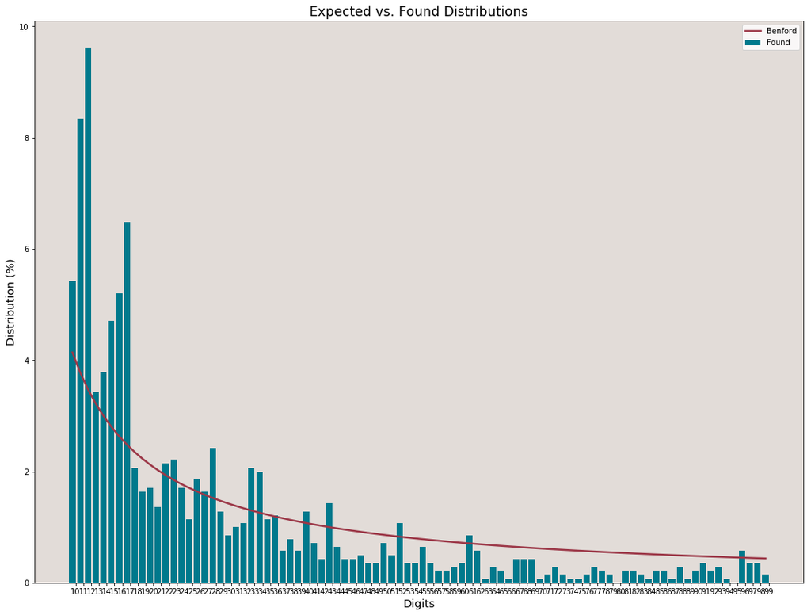

```python
teste_2digitos = bf.first_digits(travel_acomodação.ACCOMMODATION, digs= 2)
```

```python
# Verificando os 10 itens com maiores contagens nos 2 primeiros digítos.
teste_2digitos.sort_values('Counts',ascending= False ).head(10)
```

| First_2_Dig | Counts | Found | Expected |
| --- | --- | --- | --- |
| 12 | 135.0 | 0.096222 | 0.034762 |
| 11 | 117.0 | 0.083393 | 0.037789 |
| 17 | 91.0 | 0.064861 | 0.024824 |
| 10 | 76.0 | 0.054170 | 0.041393 |
| 16 | 73.0 | 0.052031 | 0.026329 |
| 15 | 66.0 | 0.047042 | 0.028029 |
| 14 | 53.0 | 0.037776 | 0.029963 |
| 13 | 48.0 | 0.034212 | 0.032185 |
| 28 | 34.0 | 0.024234 | 0.015240 |
| 23 | 31.0 | 0.022096 | 0.018483 |

Vemos que existem vários picos no teste dos 2 primeiros digítos. Vamos ver como o dataset se comporta no teste da soma.

O teste de soma analisa os primeiros dois dígitos nos dados agrupando os registros dos primeiros dois dígitos e depois calculando a soma de cada grupo.

Montantes com os mesmos dois primeiros dígitos, como 1200, 125, 12, 1234 por exemplo, são somados. Usando os valores calculados e somados, o processo determina se uma distribuição uniforme é seguida.

O teste de soma identifica números excessivamente grandes em comparação com o restante dos dados. O teste é baseado em somas e não em contagens, como nos outros testes da lei de Benford. Em teoria, as somas de números com os mesmos dois primeiros dígitos devem ser iguais em distribuição. No entanto, em conjuntos de dados normais, existem duplicações anormais regulares de grandes números que podem ser causadas por alguns números muito grandes ou um volume alto de números moderadamente grandes. Análises adicionais serão necessárias nesse caso.

```
Initialized sequence with 1403 registries.

Test performed on 1403 registries.

The top 10 diferences are:

         Sum   Percent    AbsDif
F2D
10   1548276  0.030522  0.019411
11   1742079  0.034343  0.023232
12   2466108  0.048616  0.037505
13   1252169  0.024685  0.013574
14   1285125  0.025335  0.014224
15   2006808  0.039562  0.028451
16   2546904  0.050209  0.039098
17   2208102  0.043530  0.032419
18    705314  0.013904  0.002793
19    973333  0.019188  0.008077
```

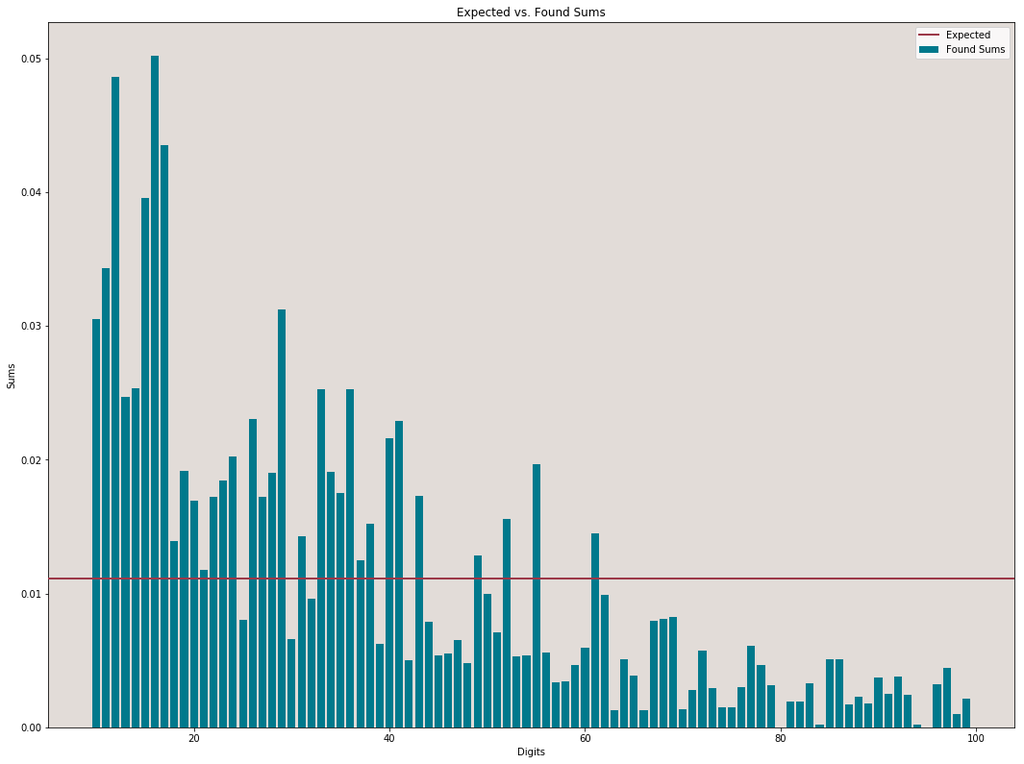

```python
teste_soma = bf.summation(travel_acomodação.ACCOMMODATION,top= 10) # Mostrar as 10 maiores diferenças.
```

Agora vamos ver a aplicação do teste de duplicação na mesma categoria para ver o seu comportamento. O resultado mostrará as 10 entradas com mais incidências.

```python
travel_dupl = bf.duplicates(travel_acomodação.ACCOMMODATION,top_Rep= 10)
```

```
Found 170 duplicated entries
The entries with the 10 highest repitition counts are:
Entries
174.02    52
123.17    39
124.30    27
168.37    27
283.68    22
111.87    22
157.07    21
113.00    20
134.47    15
271.20    12
Name: Count, dtype: int64
```

```python
travel_acomodação[(travel_acomodação['ACCOMMODATION'] == 123.17)|
                 (travel_acomodação['ACCOMMODATION'] ==124.30)]
```

|  | EMPLOYEE_NO | START_DATE_DATE | START_DATE_TIME | END_DATE_DATE | END_DATE_TIME | AIR_FARE | OTHER_TRANSPORTATION | ACCOMMODATION | MEALS | INCIDENTALS | SUBTOTAL | HOSPITALITY | OTHER_EXPENSES | TOTAL | DESTINATION | MINISTRY | POSITION | PURPOSE |
| --- | --- | --- | --- | --- | --- | --- | --- | --- | --- | --- | --- | --- | --- | --- | --- | --- | --- | --- |
| 28 | 1160 | 2010-02-24 | 2019-09-19 | 2010-03-22 | 2019-09-19 | 832.58 | 123.20 | 124.30 | 0.00 | 0.00 | 1080.08 | 0.00 | 0.00 | 1080.08 | Kingston ON, Sudbury ON, Durham ON & York ON | Education | Assistant Deputy Minister | 4 Best Start Networks Meetings |
| 356 | 1013 | 2010-05-06 | 2019-09-19 | 2010-05-07 | 2019-09-19 | 578.35 | 156.00 | 124.30 | 34.13 | 0.00 | 892.78 | 0.00 | 0.00 | 892.78 | Ottawa, ON | Office of the Premier | Staff to Minister | To provide technical support for Premier and S... |
| 630 | 1420 | 2010-06-08 | 2019-09-19 | 2010-06-09 | 2019-09-19 | 0.00 | 0.00 | 124.30 | 8.75 | 0.00 | 133.05 | 0.00 | 0.00 | 133.05 | Toronto, ON | Agriculture, Food and Rural Affairs | Deputy Minister | Travel for Federal/Provincial/Territorial Depu... |
| 678 | 1084 | 2010-06-13 | 2019-09-19 | 2010-06-14 | 2019-09-19 | 794.60 | 0.00 | 123.17 | 12.20 | 0.00 | 929.97 | 0.00 | 0.00 | 929.97 | Sault Ste. Marie, ON | Education | Deputy Minister | Travel for School Visit and attended Ground Br... |
| 695 | 1413 | 2010-06-14 | 2019-09-19 | 2010-06-14 | 2019-09-19 | 0.00 | 0.00 | 124.30 | 20.79 | 0.00 | 145.09 | 0.00 | 0.00 | 145.09 | Ottawa, ON | Office of the Premier | Staff to Minister | Provided Support to Premier at Full day learni... |
| 861 | 1090 | 2010-07-04 | 2019-09-19 | 2010-07-29 | 2019-09-19 | 0.00 | 15.00 | 123.17 | 0.00 | 0.00 | 138.17 | 0.00 | 0.00 | 138.17 | London, ON | Community Safety and Correctional Services | Commissioner - Community Safety | Routine expenses related to the ministry's ope... |
| 942 | 1334 | 2010-07-14 | 2019-09-19 | 2010-07-15 | 2019-09-19 | 682.99 | 0.00 | 123.17 | 35.82 | 0.00 | 841.98 | 0.00 | 0.00 | 841.98 | Sudbury and Sault Ste Marie, On | Northern Development and Mines | Deputy Minister | Travel to visit Ministry Offices, attend staff... |
| 955 | 1009 | 2010-07-19 | 2019-09-19 | 2010-07-19 | 2019-09-19 | 0.00 | 0.00 | 123.17 | 24.61 | 0.00 | 147.78 | 0.00 | 0.00 | 147.78 | Cobourg and Cornwall | Attorney General | Staff to Minister | Accompanied Minister at Justice on Target, CRI... |
| 957 | 1027 | 2010-07-19 | 2019-09-19 | 2010-07-20 | 2019-09-19 | 0.00 | 0.00 | 123.17 | 0.00 | 0.00 | 123.17 | 0.00 | 0.00 | 123.17 | Cobourg and Cornwall, ON | Attorney General | Minister | To attend Justice on Target Visit; CRIA announ... |
| 963 | 1334 | 2010-07-19 | 2019-09-19 | 2010-07-20 | 2019-09-19 | 1033.16 | 16.95 | 123.17 | 25.39 | 0.00 | 1198.67 | 0.00 | 0.00 | 1198.67 | Sault Ste Marie, ON | Northern Development and Mines | Deputy Minister | Travel to attend Forestry Reform Stakeholder's... |
| 964 | 1339 | 2010-07-19 | 2019-09-19 | 2010-07-19 | 2019-09-19 | 0.00 | 0.00 | 123.17 | 0.00 | 0.00 | 123.17 | 0.00 | 0.00 | 123.17 | Cobourg and Cornwall | Attorney General | Staff to Minister | Attended Justice on Target Visit, CRIA announc... |
| 1097 | 1141 | 2010-08-10 | 2019-09-19 | 2010-08-11 | 2019-09-19 | 535.90 | 64.50 | 124.30 | 42.95 | 0.00 | 767.65 | 0.00 | 0.00 | 767.65 | Thunder Bay, ON | Transportation | Assistant Deputy Minister | Routine expenses related to the ministry's ope... |
| 1103 | 1377 | 2010-08-10 | 2019-09-19 | 2010-08-11 | 2019-09-19 | 637.60 | 70.00 | 124.30 | 20.00 | 0.00 | 851.90 | 0.00 | 0.00 | 851.90 | Thunder Bay, ON | Aboriginal Affairs | Assistant Deputy Minister | Travel for Ministry of Transportation meetings |
| 1216 | 1092 | 2010-08-17 | 2019-09-19 | 2010-08-31 | 2019-09-19 | 0.00 | 0.00 | 123.17 | 92.57 | 0.00 | 215.74 | 0.00 | 0.00 | 215.74 | Toronto, ON | Natural Resources | Assistant Deputy Minister | Ministry Meetings |
| 1234 | 1202 | 2010-08-19 | 2019-09-19 | 2010-08-20 | 2019-09-19 | 763.11 | 6.00 | 124.30 | 8.75 | 0.00 | 902.16 | 0.00 | 0.00 | 902.16 | Thunder Bay | Natural Resources | Minister | Minister met with First Nations Chiefs |
| 1289 | 1248 | 2010-08-26 | 2019-09-19 | 2010-08-27 | 2019-09-19 | 0.00 | 131.08 | 124.30 | 80.00 | 0.00 | 335.38 | 0.00 | 0.00 | 335.38 | Windsor, ON | Tourism and Culture | Staff to Minister | To accompany the Minister in the Convention De... |
| 1295 | 1063 | 2010-08-27 | 2019-09-19 | 2010-08-28 | 2019-09-19 | 0.00 | 0.00 | 123.17 | 0.00 | 0.00 | 123.17 | 0.00 | 0.00 | 123.17 | Windsor, ON | Tourism and Culture | Minister | Announcement of the convention development fun... |
| 1297 | 1342 | 2010-08-27 | 2019-09-19 | 2010-08-27 | 2019-09-19 | 0.00 | 0.00 | 123.17 | 0.00 | 0.00 | 123.17 | 0.00 | 0.00 | 123.17 | Windsor, ON | Tourism and Culture | Staff to Minister | Announcement of Convention Development Fund, S... |
| 1449 | 1122 | 2010-09-20 | 2019-09-19 | 2010-09-20 | 2019-09-19 | 0.00 | 0.00 | 123.17 | 0.00 | 0.00 | 123.17 | 0.00 | 0.00 | 123.17 | London and St Thomas, ON | Agriculture, Food and Rural Affairs | Staff to Minister | Minister's trip to the International Plowing M... |
| 1464 | 1416 | 2010-09-20 | 2019-09-19 | 2010-09-20 | 2019-09-19 | 0.00 | 0.00 | 123.17 | 0.00 | 0.00 | 123.17 | 0.00 | 0.00 | 123.17 | London, ON | Environment | Staff to Minister | Drove the Hon. John Wilkinson to attend Int'l ... |
| 1467 | 1442 | 2010-09-20 | 2019-09-19 | 2010-09-21 | 2019-09-19 | 0.00 | 152.80 | 123.17 | 0.00 | 0.00 | 275.97 | 0.00 | 0.00 | 275.97 | Burlington, London, ON | Transportation | Staff to Minister | Ministerial Events |
| 1505 | 1300 | 2010-09-22 | 2019-09-19 | 2010-09-23 | 2019-09-19 | 355.75 | 0.00 | 124.30 | 40.00 | 0.00 | 520.05 | 0.00 | 0.00 | 520.05 | Thunder Bay, ON | Attorney General | Assistant Deputy Attorney General | Attended divisional learning event |
| 1519 | 1235 | 2010-09-23 | 2019-09-19 | 2010-09-24 | 2019-09-19 | 1140.51 | 146.95 | 123.17 | 8.75 | 0.00 | 1419.38 | 0.00 | 0.00 | 1419.38 | Sault Ste Marie, ON | Natural Resources | Assistant Deputy Minister | Attended Ministry Meetings. |
| 1555 | 1302 | 2010-09-27 | 2019-09-19 | 2010-09-28 | 2019-09-19 | 603.70 | 45.00 | 124.30 | 16.70 | 0.00 | 789.70 | 0.00 | 17.31 | 807.01 | Thunder Bay, ON | Natural Resources | Assistant Deputy Minister | Regular Business Travel and one group meal. |
| 1700 | 1334 | 2010-10-13 | 2019-09-19 | 2010-10-14 | 2019-09-19 | 0.00 | 0.00 | 123.17 | 0.00 | 0.00 | 123.17 | 0.00 | 0.00 | 123.17 | Sudbury, ON | Northern Development, Mines and Forestry | Deputy Minister | Travel to attend Manager's Retreat |
| 1703 | 1443 | 2010-10-13 | 2019-09-19 | 2010-10-14 | 2019-09-19 | 0.00 | 0.00 | 123.17 | 13.42 | 0.00 | 136.59 | 0.00 | 0.00 | 136.59 | Sudbury, ON | Northern Development, Mines and Forestry | Assistant Deputy Minister | Travel for Managers Meeting |
| 1707 | 1215 | 2010-10-14 | 2019-09-19 | 2010-10-15 | 2019-09-19 | 1255.80 | 0.00 | 124.30 | 14.69 | 0.00 | 1394.79 | 0.00 | 0.00 | 1394.79 | Sioux Lookout, ON | Health and Long Term Care | Staff to Minister | Grand Opening of Health Centre & Meeting with ... |
| 1711 | 1277 | 2010-10-14 | 2019-09-19 | 2010-10-15 | 2019-09-19 | 1255.80 | 0.00 | 124.30 | 14.69 | 0.00 | 1394.79 | 0.00 | 0.00 | 1394.79 | Sioux Lookout, On | Health and Long Term Care | Minister | Grand opening of Health Centre & meeting with ... |
| 1730 | 1070 | 2010-10-18 | 2019-09-19 | 2010-10-18 | 2019-09-19 | 521.21 | 69.35 | 123.17 | 0.00 | 0.00 | 713.73 | 0.00 | 0.00 | 713.73 | Ottawa, ON | Finance | Staff to Minister | Speaking Engagement at Stakeholder Meeting |
| 1797 | 1377 | 2010-10-23 | 2019-09-19 | 2010-10-24 | 2019-09-19 | 579.97 | 65.60 | 124.30 | 0.00 | 0.00 | 769.87 | 0.00 | 0.00 | 769.87 | Webequie, ON | Aboriginal Affairs | Assistant Deputy Minister | Travel for meeting with stakeholders |
| ... | ... | ... | ... | ... | ... | ... | ... | ... | ... | ... | ... | ... | ... | ... | ... | ... | ... | ... |
| 1932 | 1139 | 2010-11-08 | 2019-09-19 | 2010-11-09 | 2019-09-19 | 0.00 | 180.40 | 123.17 | 19.64 | 0.00 | 323.21 | 0.00 | 0.00 | 323.21 | London, ON | Education | Assistant Deputy Minister | Speaking Engagement - Schools in the Middle |
| 1946 | 1430 | 2010-11-08 | 2019-09-19 | 2010-11-09 | 2019-09-19 | 1027.79 | 58.30 | 123.17 | 58.12 | 0.00 | 1267.38 | 0.00 | 0.00 | 1267.38 | Sault Ste. Marie, ON | Northern Development, Mines and Forestry | Staff to Minister | Forestry Training Session |
| 2007 | 1013 | 2010-11-18 | 2019-09-19 | 2010-11-19 | 2019-09-19 | 0.00 | 46.49 | 124.30 | 9.59 | 55.06 | 235.44 | 0.00 | 0.00 | 235.44 | London, ON | Office of the Premier | Staff to Minister | To provide technical support for Minister of F... |
| 2033 | 1421 | 2010-11-22 | 2019-09-19 | 2010-11-23 | 2019-09-19 | 1065.59 | 71.00 | 124.30 | 0.00 | 0.00 | 1260.89 | 0.00 | 0.00 | 1260.89 | Thunder Bay, ON | Government Services | Deputy Minister | Travel for meetings |
| 2072 | 1129 | 2010-11-29 | 2019-09-19 | 2010-11-30 | 2019-09-19 | 0.00 | 0.00 | 123.17 | 15.60 | 0.00 | 138.77 | 0.00 | 0.00 | 138.77 | Sarnia, ON | Labour | Minister | Keynote speaker at Ministry-related event |
| 2073 | 1165 | 2010-11-29 | 2019-09-19 | 2010-11-30 | 2019-09-19 | 0.00 | 0.00 | 123.17 | 28.92 | 0.00 | 152.09 | 0.00 | 0.00 | 152.09 | Sarnia, ON | Labour | Staff to Minister | Accompanying/driving Minister Peter Fonseca to... |
| 2079 | 1402 | 2010-11-29 | 2019-09-19 | 2010-11-30 | 2019-09-19 | 0.00 | 0.00 | 123.17 | 33.90 | 0.00 | 157.07 | 0.00 | 0.00 | 157.07 | Sarnia, ON | Labour | Staff to Minister | Accompanying/driving Minister Peter Fonseca to... |
| 2090 | 1360 | 2010-11-30 | 2019-09-19 | 2010-12-01 | 2019-09-19 | 0.00 | 156.01 | 123.17 | 11.41 | 0.00 | 290.59 | 0.00 | 0.00 | 290.59 | Windsor, On | Economic Development and Trade | Staff to Minister | Staffing Minister Pupatello-CS Windsor Announc... |
| 2145 | 1376 | 2010-12-08 | 2019-09-19 | 2010-12-09 | 2019-09-19 | 0.00 | 80.00 | 123.17 | 0.00 | 0.00 | 203.17 | 0.00 | 0.00 | 203.17 | London, ON | Municipal Affairs and Housing | Assistant Deputy Minister | Travel for the purpose of attending the South ... |
| 2150 | 1115 | 2010-12-09 | 2019-09-19 | 2010-12-10 | 2019-09-19 | 0.00 | 199.60 | 124.30 | 20.00 | 0.00 | 343.90 | 0.00 | 0.00 | 343.90 | Kingston, ON | Government Services | Assistant Deputy Minister | Travel for Customer Care and Central Services ... |
| 2156 | 1360 | 2010-12-09 | 2019-09-19 | 2010-12-10 | 2019-09-19 | 0.00 | 84.62 | 123.17 | 13.66 | 58.53 | 279.98 | 0.00 | 0.00 | 279.98 | Windsor, On | Economic Development and Trade | Staff to Minister | Staffed Minister Pupatello-Windsor Strategic S... |
| 2248 | 1334 | 2011-01-11 | 2019-09-19 | 2011-01-12 | 2019-09-19 | 700.83 | 35.00 | 124.30 | 0.00 | 0.00 | 860.13 | 29.95 | 0.00 | 890.08 | Sault Ste Marie and Thunder Bay, ON | Northern Development, Mines and Forestry | Deputy Minister | Travel for meetings with stakeholders and staf... |
| 2260 | 1430 | 2011-01-12 | 2019-09-19 | 2011-01-13 | 2019-09-19 | 0.00 | 102.89 | 124.30 | 31.25 | 10.08 | 268.52 | 0.00 | 0.00 | 268.52 | Thunder Bay, ON | Northern Development, Mines and Forestry | Staff to Minister | Forest Tenure Announcement, Tour of Abitibi-Bo... |
| 2284 | 1038 | 2011-01-17 | 2019-09-19 | 2011-01-18 | 2019-09-19 | 0.00 | 0.00 | 124.30 | 15.28 | 0.00 | 139.58 | 0.00 | 0.00 | 139.58 | Kingston-Peterborough, ON | Energy and Infrastructure | Staff to Minister | Staffed Minister at the Eastern Energy Tour |
| 2287 | 1111 | 2011-01-17 | 2019-09-19 | 2011-01-18 | 2019-09-19 | 0.00 | 0.00 | 124.30 | 45.00 | 0.00 | 169.30 | 0.00 | 0.00 | 169.30 | Kingston-Peterborough, ON | Energy and Infrastructure | Minister | Eastern Energy Tour |
| 2377 | 1022 | 2011-01-27 | 2019-09-19 | 2011-02-01 | 2019-09-19 | 1761.19 | 200.87 | 123.17 | 52.35 | 13.40 | 2150.98 | 0.00 | 0.00 | 2150.98 | Sault Ste Marie, On | Office of the Premier | Staff to Minister | Providing operational support to the Premier d... |
| 2378 | 1060 | 2011-01-27 | 2019-09-19 | 2011-01-28 | 2019-09-19 | 0.00 | 180.12 | 124.30 | 0.00 | 0.00 | 304.42 | 0.00 | 0.00 | 304.42 | Kingston, ON | Francophone Affairs | Assistant Deputy Minister | To attend the launch of the Association canadi... |
| 2384 | 1241 | 2011-01-27 | 2019-09-19 | 2011-01-28 | 2019-09-19 | 0.00 | 146.47 | 123.17 | 0.00 | 0.00 | 269.64 | 0.00 | 0.00 | 269.64 | Windsor, On | Office of the Premier | Staff to Minister | Advanced and provided operational support to t... |
| 2401 | 1013 | 2011-01-31 | 2019-09-19 | 2011-02-01 | 2019-09-19 | 1142.66 | 64.95 | 123.17 | 0.00 | 0.00 | 1330.78 | 0.00 | 0.00 | 1330.78 | Sault Ste Marie, On | Office of the Premier | Staff to Minister | To provide technical support for Premier and s... |
| 2405 | 1102 | 2011-01-31 | 2019-09-19 | 2011-02-01 | 2019-09-19 | 1142.66 | 60.00 | 123.17 | 23.72 | 12.00 | 1361.55 | 0.00 | 0.00 | 1361.55 | Sault Ste Marie, On | Office of the Premier | Staff to Minister | Advanced and provided operational support for ... |
| 2407 | 1169 | 2011-01-31 | 2019-09-19 | 2011-02-01 | 2019-09-19 | 673.62 | 30.00 | 123.17 | 21.13 | 0.00 | 847.92 | 0.00 | 0.00 | 847.92 | Sault Ste Marie, On | Office of the Premier | Staff to Minister | Provided Media support to Premier at Rotary Cl... |
| 2435 | 1333 | 2011-02-02 | 2019-09-19 | 2011-02-03 | 2019-09-19 | 0.00 | 76.28 | 124.30 | 18.90 | 0.00 | 219.48 | 0.00 | 0.00 | 219.48 | Kingston, On | Office of the Premier | Staff to Minister | Provided media support to Premier McGuinty at ... |
| 2466 | 1013 | 2011-02-07 | 2019-09-19 | 2011-02-09 | 2019-09-19 | 0.00 | 139.57 | 123.17 | 7.00 | 0.00 | 269.74 | 0.00 | 0.00 | 269.74 | London, On | Office of the Premier | Staff to Minister | Provided technical support to Premier at Londo... |
| 2566 | 1102 | 2011-02-18 | 2019-09-19 | 2011-02-19 | 2019-09-19 | 0.00 | 381.16 | 124.30 | 0.00 | 0.00 | 505.46 | 0.00 | 0.00 | 505.46 | Vaughan, Barrie and Bellieve, On | Office of the Premier | Staff to Minister | Provided operational support to the Premier at... |
| 2606 | 1241 | 2011-02-24 | 2019-09-19 | 2011-02-24 | 2019-09-19 | 0.00 | 0.00 | 124.30 | 0.00 | 0.00 | 124.30 | 0.00 | 0.00 | 124.30 | Belleville, On | Office of the Premier | Staff to Minister | Advanced and provided operational support to t... |
| 2609 | 1333 | 2011-02-24 | 2019-09-19 | 2011-02-24 | 2019-09-19 | 0.00 | 176.11 | 124.30 | 11.29 | 0.00 | 311.70 | 0.00 | 0.00 | 311.70 | Barrie/Belleville, On | Office of the Premier | Staff to Minister | Provided media support to Premier McGuinty at ... |
| 2672 | 1329 | 2011-03-03 | 2019-09-19 | 2011-03-04 | 2019-09-19 | 682.80 | 0.00 | 124.30 | 20.00 | 0.00 | 827.10 | 0.00 | 17.50 | 844.60 | Thunder Bay, ON | Training, Colleges and Universities | Deputy Minister | Travel for Postsecondary Institution visits |
| 2706 | 1022 | 2011-03-10 | 2019-09-19 | 2011-03-10 | 2019-09-19 | 0.00 | 0.00 | 123.17 | 0.00 | 0.00 | 123.17 | 0.00 | 0.00 | 123.17 | Ottawa. On | Office of the Premier | Staff to Minister | Addendum to advance trip to and provide operat... |
| 2734 | 1285 | 2011-03-17 | 2019-09-19 | 2011-03-19 | 2019-09-19 | 0.00 | 241.56 | 123.17 | 7.91 | 0.00 | 372.64 | 0.00 | 0.00 | 372.64 | Windsor, On | Attorney General | Staff to Minister | Attended Regional Alcohol Consultation (Liquor... |
| 2757 | 1139 | 2011-03-23 | 2019-09-19 | 2011-03-24 | 2019-09-19 | 0.00 | 61.60 | 123.17 | 20.00 | 0.00 | 204.77 | 0.00 | 0.00 | 204.77 | Barrie, ON | Education | Assistant Deputy Minister | Schools in the Middle Sessions |

66 rows × 18 columns

O NDT é um bom provedor de informações detalhadas para identificar picos no teste de somatória e no teste dos dois primeiros dígitos. Isso ajuda a determinar se é necessária uma maior investigação.

Com relação a documentação para a biblioteca benford_py, onde é possível realizar outros testes da Lei de Benford como alterar alguns parâmetros que se adequem melhor a cada necessidade, favor consultar a documentação do pacote clicando [aqui](https://github.com/milcent/benford_py).